# 0500-inconinput-empiricalyang-33scatter

Kathryn Schuler

This experiment was conducted by Kathryn Schuler (graduate student), Jaclyn Horowitz (lab manager), and Elissa Newport (advisor) and was based on a theory and computational model proposed by Charles Yang (U. Penn). The lab manager at the time of running was Jaclyn Horowitz and the research assistant involved in this project was Rebecca Rennert (undergraduate RA). The data was collected at Georgetown University and the Arlington YMCA from October 26, 2016 to December 8, 2016.

- This experiment was reported in:
  - nothing, yet.
- And is planned to be reported in:
  - 2017 - CogSci poster (abstract submission in preparation)
  - 2017 - Katie’s dissertation

# Introduction

Children exposed to inconsistent language variation are known to regularize this variation in their productions (e.g. Singleton & Newport, 2004; Hudson-Kam & Newport, 2005). Existing demonstrations of regularization observe this behavior when the signal-to-noise ratio is as low as 40% (Austin, Schuler, Furlong, & Newport, in prep), but whether regularization occurs when the majority variant is even less widespread has not been investigated. A recent computational model, the Sufficiency Principle, quantifies when a pattern is widespread enough to be generalized (Yang, 2016): Let R be a generalization over N items, of which M items are attested to follow R. R can be extended to all N items iff: `N-M<N/ln(N)`. We exposed children to an artificial language in which the majority variant was below the threshold predicted for generalization in this model. We found that, as predicted, children do not regularize the majority variant in their productions under these circumstances. Thus, regularization may be governed by a basic principle of generalization that is well captured by this model.

# Materials and Method

## Materials

### Equipment

- Child and adult versions are the same (lab computer)
  - Hardware:
    - Macbook Air (OSX)
    - Sennheiser HD555 open-air headphones
    - Internal microphone of Macbook Air
  - Software: Python, PsychoPy
    - Note: Audacity used for some recordings as PsychoPy’s microphone API unreliable

### Language

- 10 total nouns:
  - 4 familiar used in exposure and test:
    - `mawg`, `clidam`, `zup`, `lapal`
  - 6 novel reserved for test:
  - `bleggin`, `daffin`, `norg`, `sep`, `flugit`, `geed`
- 1 verb: `gentif` (means “there is” or “there are”)
- 7 plural markers:
  - 1 majority form applied to 33% of noun instances:
    - in Language A: `ka`
    - in Language B: `po`
  - 6 minority forms (scatter), each applied to 11% of noun instances:
    - in Language A: `po`, `lee`, `bae`, `tay`, `muy`, `woo`
    - in Language B: `ka`, `lee`, `bae`, `tay`, `muy`, `woo`
- Sentences constructed:
  - Singular: `V` + `N` + `null` (e.g. `gentif mawg`)
  - Plural: `V` + `N` + `MARKER` (e.g. `gentif mawg ka`)

### Stimuli

- Images of “toasters” and pre-recorded words (adult female voice)
- Exposure set:
  - 96 total sentences paired with corresponding singular or plural pictures
  - each noun is paired with a specific plural marker (see Language)
  - 1/4 of presentations were singular and 3/4 plural for each noun
  - plural pictures appeared as 2, 4, or 6 images of the noun
  - Uniform distribution
- Production test set:
  - All novel nouns presented twice: `bleggin`, `daffin`, `norg`, `sep`, `flugit`, `geed`
  - plural pictures appeared as 3 or 5 images of then noun
- Rating test set:

## Procedure

- Exposure:
  - see a picture and hear the sentence that goes with the picture
  - repeat the sentence
  - break every 24 trials (for sticker)
- Production test:
  - modeled after wug test (Berko, 1958)
  - see a singular picture and hear corresponding sentence
  - participant asked to produce plural sentence for same noun
  - production test is dividing into two, with familiars in one half and novels in the other
    - half of the children were tested on novel nouns first
    - half of the children were tested on familiar nouns first
- Rating test:
  - familiar nouns only
  - see picture and hear corresponding sentence
  - rate on a scale of 1 to 5 (give 1 to 5 stars)

# Results and analysis

## Participants

### Included in analysis

The following describes the participants that were included in analysis for both the child and adult age groups.

| age.group | n.subjs | n.female | min.age | max.age | mean.age | sd.age |
| --- | --- | --- | --- | --- | --- | --- |
| adult | 11 | 8 | 18.04 | 21.50 | 19.19909 | 1.0653211 |
| child | 8 | 5 | 4.94 | 6.75 | 6.03875 | 0.5630386 |

## Production Data

We ask the following questions in our analysis (for both children and adults):

- Does the Sufficiency Principle predict when learners will generalize the majority variant?
  - Do learners use the majority variant on 100% of test trials (strongly generalize/regularize)?
  - Or do learners use the majority variant no more than what we expect by chance (strongly resist generalization)?
  - Or do learners match the input frequency of the majority variant (probability match)?

### Group data

Usage of variant in production test by age group

| Age | Variant | Mean | SD | SEM |
| --- | --- | --- | --- | --- |
| child | maj | 16.80 | 34.83 | 12.31 |
| child | min | 49.05 | 42.77 | 15.12 |
| child | null | 0.00 | 0.00 | 0.00 |
| child | other | 34.15 | 40.80 | 14.42 |
| adult | maj | 30.68 | 17.31 | 5.22 |
| adult | min | 63.64 | 21.09 | 6.36 |
| adult | null | 0.00 | 0.00 | 0.00 |
| adult | other | 5.68 | 9.37 | 2.82 |

#### Plot of group data

The dashed red line indicates the frequency of the majoirty form in the learner’s exposure.

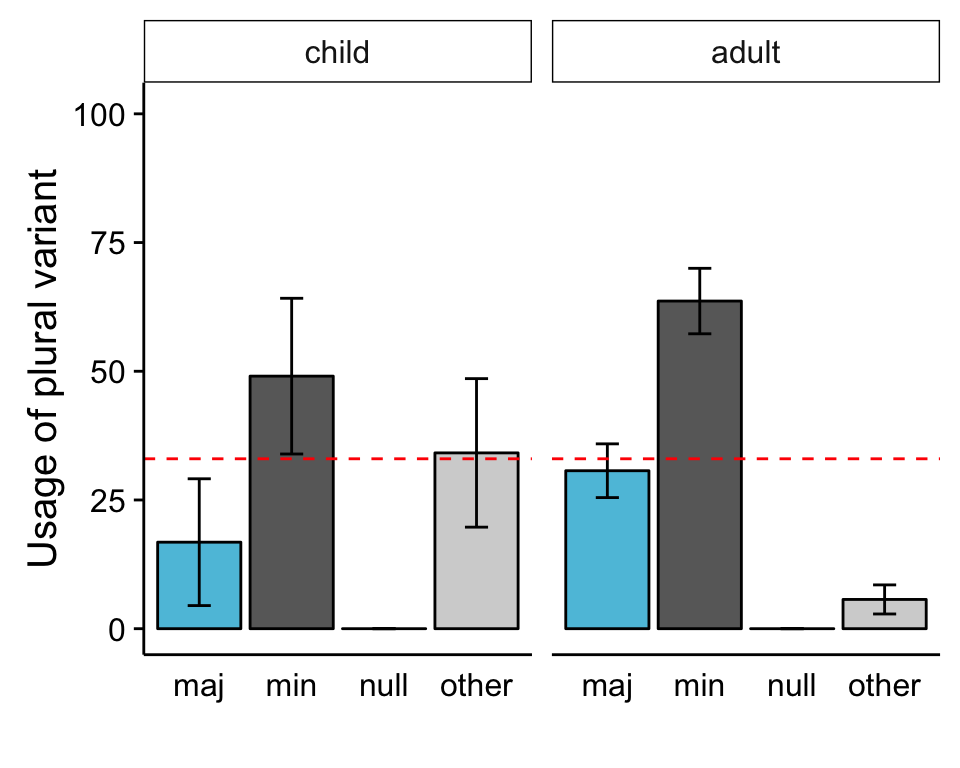

#### Children

Results of t-tests against hypotheized vaules for usage of the majority variant.

|  | alternative | t.statistic | df | p.value | sig |
| --- | --- | --- | --- | --- | --- |
| Strong regularization (100%) | less | -6.756397 | 7 | 0.0001317 | *** |
| Strongly resist regularization (14.29%) | greater | 0.204041 | 7 | 0.4220634 | n.s |
| Probability matching (33.00%) | not equal | -1.315383 | 7 | 0.2298267 | n.s. |

#### Adults

Results of t-tests against hypotheized vaules for usage of the majority variant.

|  | alternative | t.statistic | df | p.value | sig |
| --- | --- | --- | --- | --- | --- |
| Strong regularization (100%) | less | -13.2832084 | 10 | 0.0000001 | *** |
| Strongly resist regularization (14.29%) | greater | 3.1411086 | 10 | 0.0052452 | *** |
| Probability matching (33.00%) | not equal | -0.4442253 | 10 | 0.6663385 | n.s. |

#### Interpretations

For adults, mean usage of the majority variant was significantly different from both 100% (p < 0.001) and 14.29% (p < 0.01), but not from 33.00% (p = 0.67), the value predicted for probability matching. This suggests that adults are matching the input probaiblity of the majority variant in their productions.

### Individual data

To determine what children are doing, we turn to the invidual data. Here we can see that the majority of children strongly resist regularization (5 of 8 children never applied the majorty form). And that our mean result may be heavily influenced by an oulier - one child who did regularize under these circumstances. If we apply a standard outlier exclusion criteria, 2 SDs from the mean (threshold = 86.46), we can recalculate our results without this outlier.

#### Plot of individual data

The dashed red line indicates the frequency of the majoirty form in the learner’s exposure.

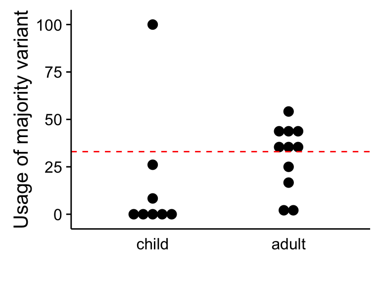

### Group data (outlier removed)

Usage of variant in production test by age group

| Age | Variant | Mean | SD | SEM |
| --- | --- | --- | --- | --- |
| child | maj | 4.92 | 9.84 | 3.72 |
| child | min | 56.06 | 40.94 | 15.47 |
| child | null | 0.00 | 0.00 | 0.00 |
| child | other | 39.02 | 41.47 | 15.67 |
| adult | maj | 30.68 | 17.31 | 5.22 |
| adult | min | 63.64 | 21.09 | 6.36 |
| adult | null | 0.00 | 0.00 | 0.00 |
| adult | other | 5.68 | 9.37 | 2.82 |

#### Plot of group data

The dashed red line indicates the frequency of the majoirty form in the learner’s exposure.

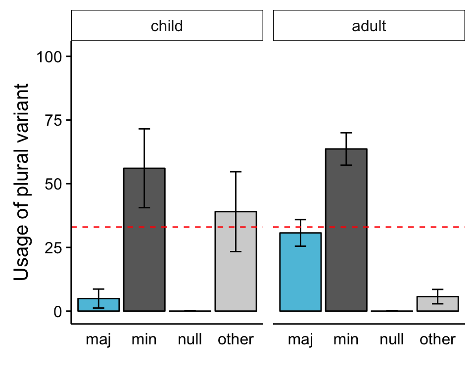

#### Children

Results of t-tests against hypotheized vaules for usage of the majority variant.

|  | alternative | t.statistic | df | p.value | sig |
| --- | --- | --- | --- | --- | --- |
| Strong regularization (100%) | less | -25.570677 | 6 | 0.0000001 | *** |
| Strongly resist regularization (14.29%) | greater | -2.520637 | 6 | 0.9773759 | n.s |
| Probability matching (33.00%) | not equal | -7.552328 | 6 | 0.0002797 | *** |

#### Individual data plot (outlier removed)

The dashed red line indicates the frequency of the majoirty form in the learner’s exposure.

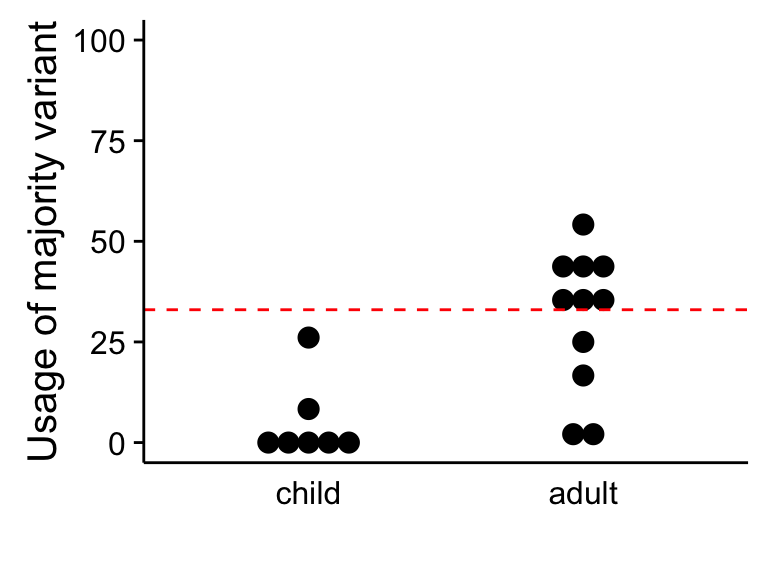

#### Revised interpretations

When the single outlying child is eliminated, the resuts become disambiguated. Children behave significanlty differently from what is expected for regularization (p<0.001) and are also behaving in a way that is highly significantly different from probability matching (p<0.001). Their behavior is instead consistent with strongly resisting regularization (p=0.97).

This suggests that when the threshold for generalization (as determined by the Sufficiency Principle) is not met, children withhold generalization and do not regularize the majority variant in their productions.

# Important files

Files can be found on Katie’s local computer at the path described, or you can access them via dropbox by clicking the links provided. Local paths are relative to: `/Users/kathrynschuler/Dropbox/Research/inconinput/inconinput-empirical-yang/0500-inconinput-empiricalyang-33scatter/`

- **Summary (this document)**: [`0500-inconinput-empiricalyang-33scatter-summary.html`](https://www.dropbox.com/s/s1eutdhb9wmljs2/0500-inconinput-empiricalyang-33scatter-summary.html?dl=0)
- **Analysis**: [`0500-inconinput-empiricalyang-33scatter-analysis`](https://www.dropbox.com/sh/r9whkmic7aj0w92/AADuPBRRRKct-oYGv__GEeiwa?dl=0)
- **Design sheet**: [`0500-inconinput-empiricalyang-33scatter-design.xslx`](https://www.dropbox.com/s/lk7c81rv44gil9e/0500-inconinput-empiricalyang-33scatter-design.xlsx?dl=0)
- **Auxiliary documents**: [`0500-inconinput-empiricalyang-33scatter-docs`](https://www.dropbox.com/sh/75mck1h5fd36eeb/AACVx7paWILTNVNzzw2WLCkSa?dl=0)
- **Experiment code**: [`0500-inconinput-empiricalyang-33scatter-exp`](https://www.dropbox.com/sh/94my0o14i0ii37h/AACwkLOgLzqQXqOiPcjAIfXGa?dl=0)
- **Processed data**: [`0500-inconinput-empiricalyang-33scatter-processed-data`](https://www.dropbox.com/sh/n4z51kphartjdjg/AAAmwomvwhvx5-fdA7Gc3bR2a?dl=0)
- **Raw data**: [`0500-inconinput-empiricalyang-33scatter-raw-data`](https://www.dropbox.com/sh/hjcvx7d0raw4zec/AAAyLI8fyQGvSf5YE5QpOYKpa?dl=0)
- **Stimuli**: [`0500-inconinput-empiricalyang-33scatter-stims`](https://www.dropbox.com/sh/724o5jiues16nq8/AAB4RyhPoC7oZ1P7787Dq7lEa?dl=0)
- **Subject tracking sheet**: [`0500-inconinput-empiricalyang-33scatter-track.csv`](https://www.dropbox.com/s/q5lf6qjswzpfkiu/0500-inconinput-empiricalyang-33scatter-track.csv?dl=0)